# GSA workflow tutorial

#### 3.3 Assess the robustness of the results (i.e. are the results sample independent?)

To assess the robustness of the sensitivity indices, bootstrapping is performed (here `Nboot = 1000`):

```r
Y = YY[, 1, drop = FALSE] # RMSE

# Define the threshold:
threshold = 3.5

Nboot <- 1000 # Number of resamples used for bootstrapping (recommended value for a rigorous analysis is 1000)
# Assess sensitivity indices with bootstrapping (WARNING: it may take some time to run this line):
rsatr_b <- RSA_indices_thres(X, Y, threshold, flag = 1, Nboot = Nboot, alfa = 0.05) # By adding the extra
# argument `Nboot` to the function `RSA_indices_thres` bootstrapping is performed,
# 'alfa' is the scalar significance level for the confidence intervals estimated by bootstrapping

stat_m <- rsatr_b$stat # mean KS over bootstrap resamples
idxb_Nb <- rsatr_b$idxb

stat_lb <- rsatr_b$stat_lb # lower bound of KS over bootstrap resamples
stat_ub <- rsatr_b$stat_ub # upper bound of KS over bootstrap resamples
```

Here the sensitivity indices with their 95% confidence intervals are plotted.

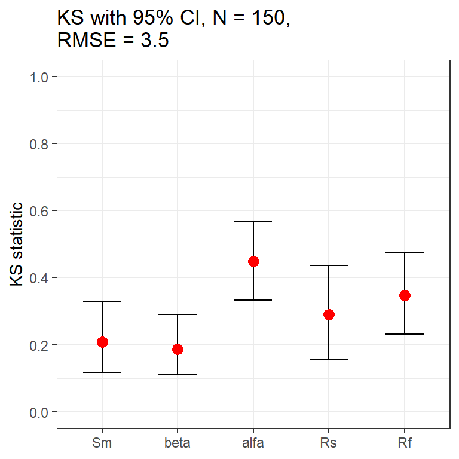

```r
boxplot1(stat_m, stat_lb, stat_ub, prnam = x_labels)  + ggtitle(paste0("KS with 95% CI, N = ",N, ", \n", colnames(Y)," = ",threshold)) + ylab("KS statistic")
```

**Questions:**  
*Are the sensitivity indices adequately estimated? Is the sample size large enough?*

$$\begin{array}{l}
-------------------------------------------------------------- \\
\\
-------------------------------------------------------------- \\
\\
-------------------------------------------------------------- \\
\end{array}$$

Try now to increase the sample size (N) and re-run the analysis.

```r
# Choose the number of samples to be added:
N_new <- 2000 # size of new samples
N2 <- N_new + N # total sample size

# Add new samples:
X_new <- AAT_sampling_extend(X, DistrFun, DistrPar, N_new)
# AAT_sampling_extend allows to extend an existing sample by choosing additional samples that maximize the spread in the input space
colnames(X_new) <- x_labels

# Combine old and new samples:
X_N2 = rbind(X,X_new)

# Compute output metrics with new sample size:

# Execute the model against the new inputs samples (WARNING: it may take some time to run this line):
QQ_new <- apply(X_new,1,hymod_sim_workshop,dat$rain,dat$evap)

# Aggregate time series into various scalar output metric(s):
YY_new <- matrix(, nrow = N_new, ncol = 2)
YY_new[,1] <- apply(QQ_new[(warmup+1):nrow(QQ_new),],2,RMSE,dat$flow[(warmup+1):nrow(dat)]) # RMSE
YY_new[,2] <- apply(QQ_new[(warmup+1):nrow(QQ_new),],2,BIAS,dat$flow[(warmup+1):nrow(dat)]) # BIAS
colnames(YY_new) <- c("RMSE","BIAS")

# Combine old and new output samples:
YY_N2 = rbind(YY,YY_new)
```

Compare the input CDFs of the behaviour and non-behavioural subsample with the new sample size:

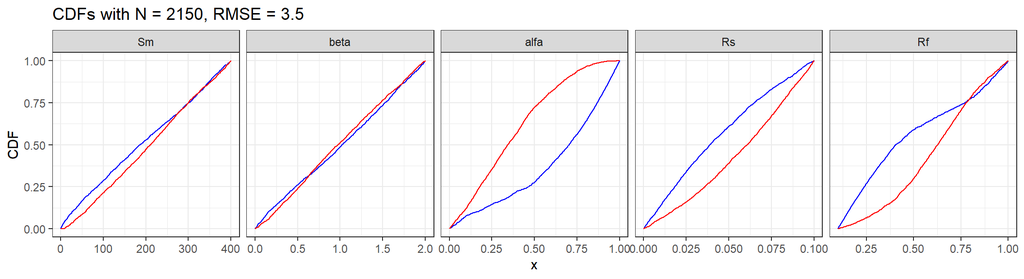

```r
# Select the output metric to be analysed (uncomment option you want to view):
Y_N2 = YY_N2[, 1, drop = FALSE] # RMSE
# Y_N2 = YY[, 2, drop = FALSE] # BIAS

# Define the threshold:
threshold = 3.5

# Use the function RSA_indices_thres to split into behavioural (Y<threshold) and non-behavioural (Y>threshold) sample:
rsatr_N2 <- RSA_indices_thres(X_N2, Y_N2, threshold)

# Recover indices of behavioural samples:
idxb_N2 <- rsatr_N2$idxb

# Plot CDFs of behavioural and non-behavioural input samples:
RSA_plot_thres(X_N2, idxb_N2, prnam = x_labels, threshold) + scale_color_manual(values=c("blue","red")) + ggtitle(paste0("CDFs with N = ",N2, ", ", colnames(Y_N2)," = ",threshold))
```

```r
# (red = behavioural, blue = non-behavioural)
```

Let’s assess the robustness of the sensitivity indices to the new sample size with bootstrapping (here `Nboot = 1000`):

```r
Nboot <- 1000 # Number of resamples used for bootstrapping

# Assess sensitivity indices with bootstrapping (WARNING: it may take some time to run this line):
rsatr_b_N2 <- RSA_indices_thres(X_N2, Y_N2, threshold, flag = 1, Nboot = Nboot, alfa = 0.05) # By adding the extra
# argument `Nboot` to the function `RSA_indices_tr` bootstrapping is performed,
# 'alfa' is the scalar significance level for the confidence intervals estimated by bootstrapping

stat_N2_m <- rsatr_b_N2$stat
idxb_N2_Nb <- rsatr_b_N2$idxb

stat_N2_lb <- rsatr_b_N2$stat_lb
stat_N2_ub <- rsatr_b_N2$stat_ub

# Check the bootstrap mean values of the KS statistic:
stat_N2_m
```

```
## [1] 0.09883522 0.06135277 0.45702561 0.23794327 0.32688652
```

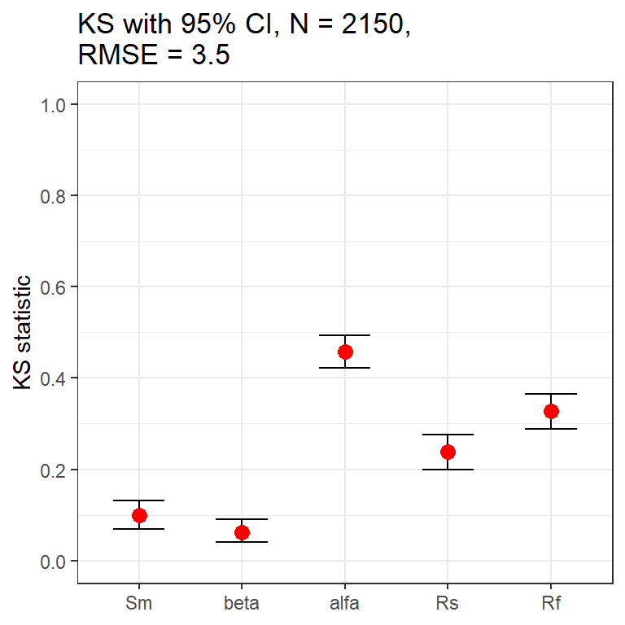

```r
# Plot the sensitivity indices with their 95% confidence intervals:
boxplot1(stat_N2_m, stat_N2_lb, stat_N2_ub, prnam = x_labels) + ggtitle(paste0("KS with 95% CI, N = ",N2, ", \n", colnames(Y_N2)," = ",threshold)) + ylab("KS statistic")
```

**Questions:**  
*Has the ranking of the parameters changed? Is the sample size large enough now?*  
*How do the KS values you obtained compare to the results of the other participants?*

$$\begin{array}{l}
-------------------------------------------------------------- \\
\\
-------------------------------------------------------------- \\
\\
-------------------------------------------------------------- \\
\end{array}$$

Repeat computations using an increasing number of samples so to assess convergence:

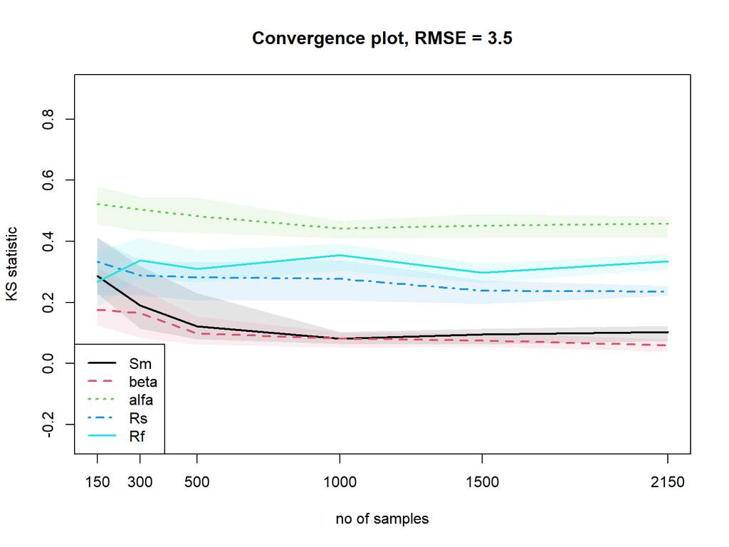

```r
NN <- c(150, 300, 500, 1000, 1500, 2150) # increasing sample sizes
Nboot <- 10 # Number of resamples used for bootstrapping

rsatr_conv <- RSA_convergence_thres(X_N2, Y_N2, flag=1, NN, threshold = threshold,
                                    Nboot = Nboot, alfa = 0.05)
stat_conv <- rsatr_conv$stat
idxb <- rsatr_conv$idxb

stat_conv_lb <- rsatr_conv$stat_lb
stat_conv_ub <- rsatr_conv$stat_ub

# Plot the sensitivity measures as a function of the number of samples:
plot_convergence(NN, stat_conv, stat_conv_lb, stat_conv_ub, xlab = "no of samples",
                 ylab = "KS statistic", labels = x_labels, ylim = c(-0.25, 0.9))
title(main=paste0('Convergence plot, ', colnames(Y_N2)," = ",threshold))
```

**Questions:**  
*Has convergence been reached? Why?*

$$\begin{array}{l}
-------------------------------------------------------------- \\
\\
-------------------------------------------------------------- \\
\\
-------------------------------------------------------------- \\
\end{array}$$

#### 3.4 Assess the effect of the definition of the input factors’ space of variability

Define new input factors’ ranges:

```r
# Define new input factors' ranges:
DistrPar2  <- list( c(0, 800), c(0, 4), c(0, 0.8), c(0, 0.4), c(0.4, 1))  # Define parameter ranges
# DistrPar  <- list( c(0, 400), c(0, 2), c(0, 1), c(0, 0.1), c(0.1, 1)) # Previous parameter ranges

# Sample input factors' space:
X_P2 <- AAT_sampling(SampStrategy, M, DistrFun, DistrPar2, N2)
colnames(X_P2) <- x_labels
```

Compare the input CDFs of the behaviour and non-behavioural subsample with the new parameterisation:

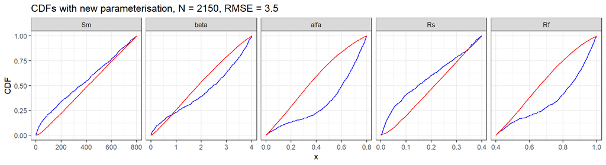

```r
# Execute the model:
QQ_P2 <- apply(X_P2,1,hymod_sim_workshop,dat$rain,dat$evap)

# Aggregate time series into various scalar output metric(s):
YY_P2 <- matrix(, nrow = N2, ncol = 2)
YY_P2[,1] <- apply(QQ_P2[(warmup+1):nrow(QQ_P2),],2,RMSE,dat$flow[(warmup+1):nrow(dat)]) # RMSE
YY_P2[,2] <- apply(QQ_P2[(warmup+1):nrow(QQ_P2),],2,BIAS,dat$flow[(warmup+1):nrow(dat)]) # BIAS
colnames(YY_P2) <- c("RMSE","BIAS")

# Select the output metric to be analysed:
Y_P2 = YY_P2[, 1, drop = FALSE] # RMSE
Y_P2 = YY_P2[, 1, drop = FALSE] # BIAS

# Define the threshold:
threshold = 3.5

# Use the function RSA_indices_thres to split into behavioural (Y<threshold) and non-behavioural (Y>threshold) sample:
rsatr_P2 <- RSA_indices_thres(X_P2, Y_P2, threshold)

# Recover indices of behavioural samples:
idxb_P2 <- rsatr_P2$idxb

# Plot CDFs of behavioural and non-behavioural input samples:
RSA_plot_thres(X_P2, idxb_P2, prnam = x_labels, threshold) + scale_color_manual(values=c("blue","red")) + ggtitle(paste0("CDFs with new parameterisation, N = ",N2, ", ", colnames(Y_P2)," = ",threshold))
```

```r
# (red = behavioural, blue = non-behavioural)
```

Calculate the sensitivity indices using bootstrapping:

```r
Nboot <- 1000 # Number of resamples used for bootstrapping

# Assess sensitivity indices with bootstrapping (WARNING: it may take some time to run this line):
rsatr_b_P2 <- RSA_indices_thres(X_P2, Y_P2, threshold, flag = 1, Nboot = Nboot, alfa = 0.05)

stat_m_P2 <- rsatr_b_P2$stat
idxb_Nb_P2 <- rsatr_b_P2$idxb

stat_lb_P2 <- rsatr_b_P2$stat_lb
stat_ub_P2 <- rsatr_b_P2$stat_ub
```

Plot the sensitivity indices with their 95% confidence intervals:

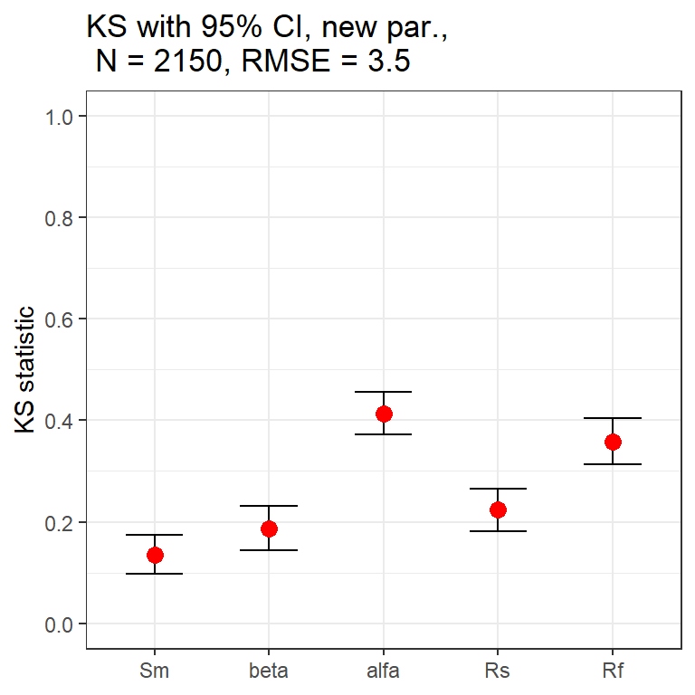

```r
boxplot1(stat_m_P2, stat_lb_P2, stat_ub_P2, prnam = x_labels) + ggtitle(paste0("KS with 95% CI, new par., \n N = ",N2, ", ", colnames(Y_P2)," = ",threshold)) + ylab("KS statistic")
```

**Questions:**  
*Is the sample size large enough?*  
*How have the sensitivity indices changed by changing their range of variability?*

$$\begin{array}{l}
-------------------------------------------------------------- \\
\\
-------------------------------------------------------------- \\
\\
-------------------------------------------------------------- \\
\end{array}$$

#### 4. Regional Sensitivity Analysis based on grouping

In this section, we assess the sensitivity using the RSA method based on grouping (Wagener et al., 2001). This variant does not require the definition of a single threshold on the output value. It consists of splitting the input factor sample into a given number of groups (e.g. ten) according to the associated output value. In our application, we use ten intervals of increasing output value, designed so to have an equal number of data points in each group. The corresponding ten CDFs are then derived for each input factor. We can apply this method to the input-output sample that we have already created.

Perform RSA based on grouping:

```r
# Select the output metric to be analysed (uncomment option you want to view):
Y_N2 = YY_N2[, 1, drop = FALSE] # RMSE
# Y = YY[, 2, drop = FALSE] # BIAS

# Set number of groups:
ngroup = 10

# Perform RSA based on grouping:
rsa_gr <- RSA_indices_groups(X_N2, Y_N2, ngroup = ngroup)

# Recover indices of the ten groups:
idx_gp <- rsa_gr$idx
# Recover range of values of the output:
Yk <- rsa_gr$Yk

# Look at the range of values of the output in the ten groups:
Yk
```

```
##  [1] 2.267454 2.908424 3.082755 3.230239 3.368403 3.501154 3.612160 3.766976
##  [9] 3.949891 4.212917 8.496640
```

Plot parameter CDFs corresponding to the ten groups:

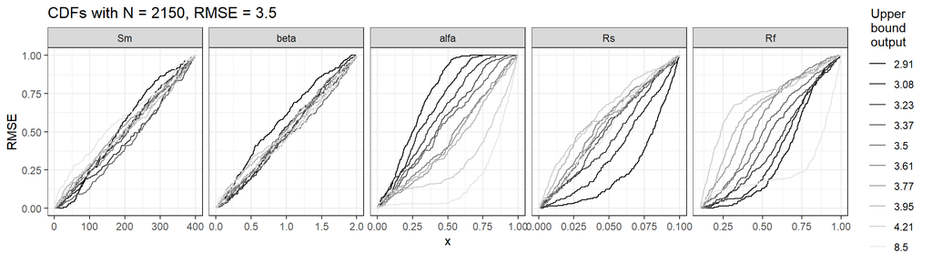

```r
RSA_plot_groups(X_N2, idx_gp, Yk, prnam = x_labels) + ylab(colnames(Y_N2)) + ggtitle(paste0("CDFs with N = ",N2, ", ", colnames(Y_N2)," = ",threshold)) + scale_color_manual(values=c("black", "grey10", "grey20", "grey30", "grey40", "grey50", "grey60", "grey70", "grey80", "grey90"))
```

**Questions:**  
*From the CDF plots, which parameter would you say is most influential? Why?*  
*Are the results of RSA based on grouping consistent with the results of RSA based on threshold?*  
*Which additional information is provided by RSA based on grouping?*

$$\begin{array}{l}
-------------------------------------------------------------- \\
\\
-------------------------------------------------------------- \\
\\
-------------------------------------------------------------- \\
\end{array}$$

Here we only performed a visual analysis of the ten CDFs, but sensitivity indices could also be computed based on the KS statistic.

#### 5. Variance-Based Sensitivity Analysis

In this section, we use Variance-Based Sensitivity Analysis (VBSA) to measure output sensitivities. We compare with the RSA results to assess the effect of the choice of the GSA method.

The **key principles** of VBSA are:
[a] The variance of the output distribution is a proxy for output uncertainty
[b] Output variance can be decomposed (under broad assumptions) in contributions from individual inputs and their interactions (Sobol, 1990)
$$V=\sum_i V_i + \sum_{i<j} V_{ij} + \sum_{i<j<k} V_{ijk}+...+V_{12...M}$$
[c] The variance contribution from an input factor is a measure of output sensitivity to that input. Two indices are commonly used (Homma and Saltelli, 1996):
$$\begin{array}{ll}
S_i = V_i/V & \text{First-order (or "main effects") index} \\
S_{T_i} = (V_i + \sum_j V_{ij} + \sum_{j<k} V_{ijk}+...)/V & \text{Total-order (or "total effects") index}
\end{array}$$

The first-order index $S_i$ measures the direct contribution to the output variance from variations of the i-th input. It has the following properties:  
i) $S_i \in [0,1]$  
ii) if $Si = 0$ then $x_i$ has no direct influence on $y$ (but it might still have some in interaction with other factors!)  
iii) The higher $Si$, the larger the direct influence of $x_i$  
iv) $\sum_i S_i <= 1$. If $\sum_i S_i = 1$ then there are no interactions between the factors

The total-order index $S_{T_i}$ measures the overall contribution from both individual variability of $x_i$ and its interactions with other inputs. It has the following properties:  
i) $S_{T_i} \in [0,1]$  
ii) if $S_{T_i} = 0$ then $x_i$ has no influence at all on $y$  
iii) The higher $S_{T_i}$, the larger the overall influence of $x_i$  
iv) $\sum_i S_{T_i} >= 1$. If $\sum_i S_{T_i} = 1$ then there are no interactions between the factors

**Approximation of VBSA sensitivity indices**. First-order and total-order indices typically cannot be computed exactly, but there are several approximation strategies to compute them from a sample of model inputs and outputs:  
[a] FAST and eFAST algorithm, which are based on Fourier transformation of the output (Cukier et al. 1973; Saltelli et al. 1999)  
[b] Algebraic approximators based on a “re-sampling” matrix (Homma and Saltelli 1996; Saltelli et al. 2010)  
[c] Nonparametric regression approaches (Strong et al. 2014; Stanfill et al. 2015)

Here we will use the second approach [b]. The steps for the algebraic approximation of first-order and total-order indices are:  
[1] Generate 2 matrices (XA and XB) of n input vectors each. This can be done using any generic random sampling technique, e.g. Latin-Hypercube or Sobol quasi-random sampling  
[2] Generate an additional matrix (XC) of M x n input vectors by resampling from XA and XB. Specifically, each of the M sub-matrices in XC has all the columns of XB but the i-th, which is taken from XA (see Saltelli et al. (2010) for details on resampling)  
[3] Execute the model against all input combinations in XA, XB and XC (the total number of model executions thus is (2+M)xn )  
[4] Compute 2 x M indices Si and STi (i=1,…,M) as:  
`f0 = mean(YA)`  
`V = mean(YA.^2) - f0^2`  
`S(i) = ( 1/N *sum(YA.*YC(i)) - f0^2 ) / V`  
`ST(i) = 1 - ( 1/N*sum(YB.*YC(i)) - f0^2 ) / V`

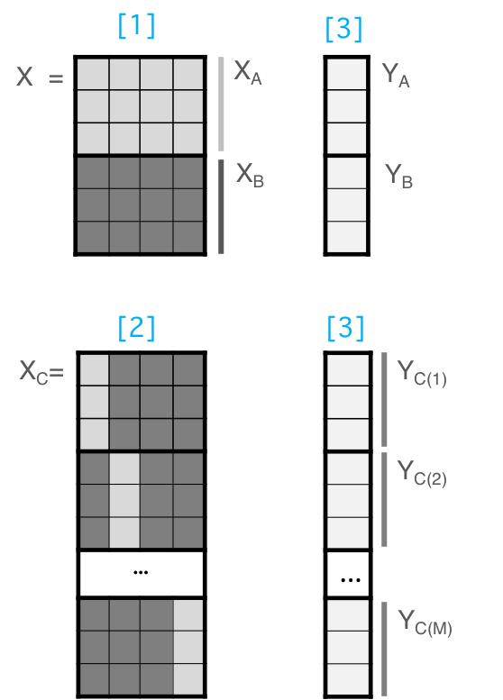

Let’s start by resampling. We can re-use the matrix X we have already generated for RSA and split it into the two matrices XA and XB. This has the advantage that we have already executed the model against these matrices, so that we will only have to execute the model against XC.

```r
# Split X into XA and XB, and obtain the resampling matrix XC:
XABC <- vbsa_resampling(X_N2)
# Check input sample dimensions:
dim(XABC$XA)
dim(XABC$XB)
dim(XABC$XC)

# Recover samples corresponding to sub-matrices XA and XB:
YYA = YY_N2[1:(N2/2),]
YYB = YY_N2[((N2/2)+1):N2,]

# Execute the new input samples (XC):
myfun <- "hymod_MulObj" # Function used to compute the model output; to check what this function does, type:
# ?hymod_MulObj
# Execute the model (WARNING: it may take some time to run this line):
YYC <- model_execution(myfun, XABC$XC, dat = dat)
colnames(YYC) <- c("RMSE","BIAS")

# Select output:
# i_out = 1 # RMSE
i_out = 2 # BIAS
YA = YYA[, i_out, drop=FALSE]
YB = YYB[, i_out, drop=FALSE]
YC = YYC[, i_out, drop=FALSE]
```

Check the model output distribution:

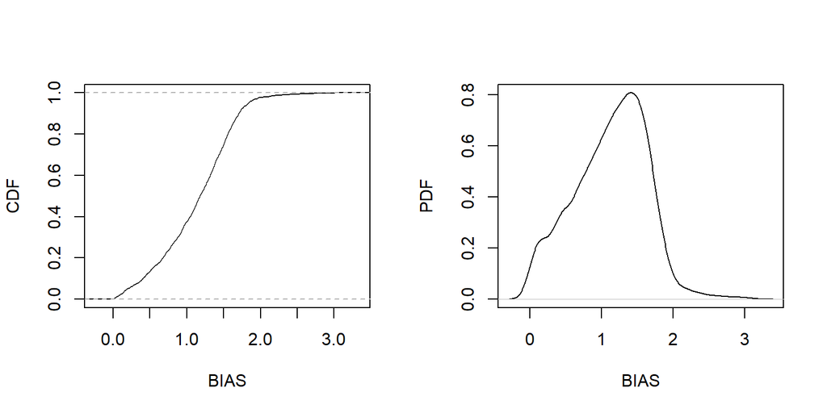

```r
Y_plot <- c(YA, YB)

par(mfrow = c(1, 2))
plot(ecdf(Y_plot), xlab = colnames(YA), ylab = "CDF", main ="")
plot(density(Y_plot), xlab = colnames(YA), ylab = "PDF", main ="")
```

**Questions:**  
*Is the distribution multi-modal or highly skewed?*  
*Is the variance-based approach adequate?*

$$\begin{array}{l}
-------------------------------------------------------------- \\
\\
-------------------------------------------------------------- \\
\\
-------------------------------------------------------------- \\
\end{array}$$

Approximate first-order and total-order sensitivity indices using bootstrapping:

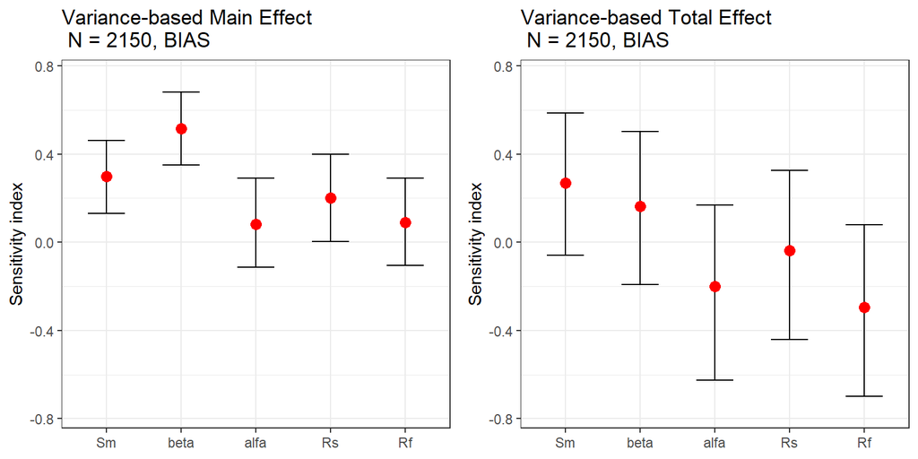

```r
# Compute confidence bounds around sensitivity indices:
Nboot <- 1000 # Choose number of bootstrap resamples
ind_vbsa <- vbsa_indices(YA,YB,YC, Nboot)
Si     <- ind_vbsa[1,] # first-order (bootstrap mean)
Si_lb  <- ind_vbsa[3,] # first-order (bootstrap lower bound)
Si_ub  <- ind_vbsa[4,] # first-order (bootstrap upper bound)
STi    <- ind_vbsa[5,] # total-order (bootstrap mean)
STi_lb <- ind_vbsa[7,] # total-order (bootstrap lower bound)
STi_ub <- ind_vbsa[8,] # total-order (bootstrap upper bound)

# Plot main and total effects with confidence bounds:
p1 <- boxplot1(Si, Si_lb, Si_ub, prnam = x_labels) +
ggtitle(paste0("Variance-based Main Effect\n N = ",N2, ", ", colnames(YA))) + ylab("Sensitivity index") + ylim(min(c(min(Si_lb), min(STi_lb)))*1.1, max(c(max(Si_ub), max(STi_ub)))*1.1)
p2 <- boxplot1(STi, STi_lb, STi_ub, prnam = x_labels) +
ggtitle(paste0("Variance-based Total Effect\n N = ",N2, ", ", colnames(YA))) + ylab("Sensitivity index") + ylim(min(c(min(Si_lb), min(STi_lb)))*1.1, max(c(max(Si_ub), max(STi_ub)))*1.1)
plot_grid(p1, p2, ncol = 2)
```

**Questions:**  
*Are the sensitivity indices robust?*  
*The sensitivity indices should be in the range 0-1. Is this verified here? Why?*  
*What is the ranking of input parameters according to these indices, and is it consistent with that of RSA?*

$$\begin{array}{l}
-------------------------------------------------------------- \\
\\
-------------------------------------------------------------- \\
\\
-------------------------------------------------------------- \\
\end{array}$$

Repeat VBSA with larger sample size (WARNING: this may take few minutes to run!)

```r
Nnew_vbsa <- 10000 # size of new sample
N2_vbsa <- Nnew_vbsa + N2 # total sample size

# Add new samples:
X_vbsa_new <- AAT_sampling_extend(X_N2, DistrFun, DistrPar, Nnew_vbsa)
XABC_new <- vbsa_resampling(X_vbsa_new)

# Execute the model against the new samples(WARNING: it may take some time to run this line):
YYA_new <- model_execution(myfun, XABC_new$XA, dat = dat)
YYB_new <- model_execution(myfun, XABC_new$XB, dat = dat)
YYC_new <- model_execution(myfun, XABC_new$XC, dat = dat)
colnames(YYA_new) <- c("RMSE","BIAS")
colnames(YYB_new) <- c("RMSE","BIAS")
colnames(YYC_new) <- c("RMSE","BIAS")

# Combine old and new output samples and extract output of interest:
YYA_2 = rbind(YYA,YYA_new)
YA_2 = YYA_2[,i_out, drop=FALSE]
YYB_2 = rbind(YYB,YYB_new)
YB_2 = YYB_2[,i_out, drop=FALSE]
YC_2_tmp = rbind(matrix(YYC[, i_out],N2/2,M),matrix(YYC_new[, i_out],Nnew_vbsa/2,M))
YC_2 = matrix(YC_2_tmp,N2_vbsa/2*M,T)

# Recompute indices
Nboot <- 1000 # Choose number of bootstrap resamples
ind2 <- vbsa_indices(YA_2,YB_2,YC_2, Nboot)
Si2     <- ind2[1,]
Si2_lb  <- ind2[3,]
Si2_ub  <- ind2[4,]
STi2    <- ind2[5,]
STi2_lb <- ind2[7,]
STi2_ub <- ind2[8,]
```

Replot the sensitivity indices with their 95% confidence intervals:

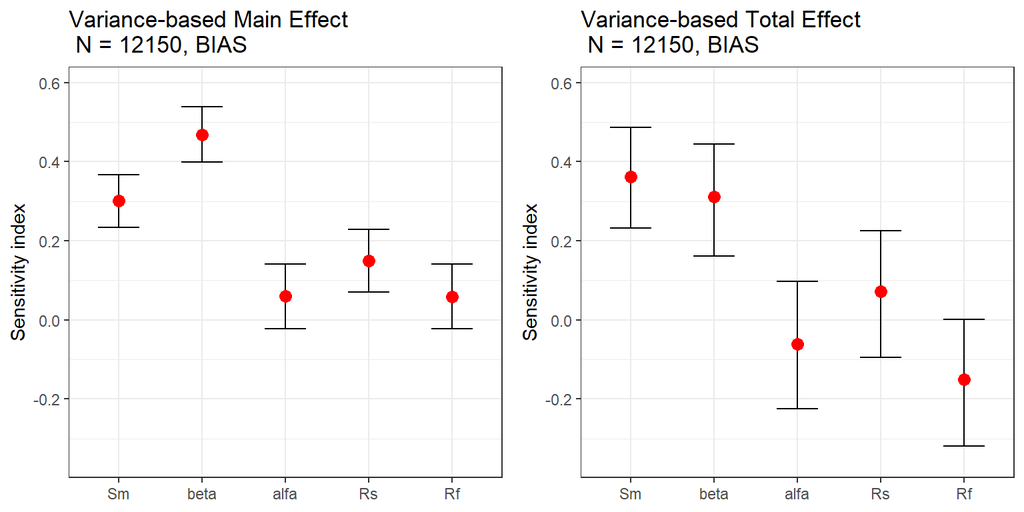

```r
p1 <- boxplot1(Si2, Si2_lb, Si2_ub, prnam = x_labels) +
ggtitle(paste0("Variance-based Main Effect\n N = ",N2_vbsa, ", ", colnames(YA_2))) + ylab("Sensitivity index") + ylim(min(c(min(Si2_lb), min(STi2_lb)))*1.1, max(c(max(Si2_ub), max(STi2_ub)))*1.1)
p2 <- boxplot1(STi2, STi2_lb, STi2_ub, prnam = x_labels) +
ggtitle(paste0("Variance-based Total Effect\n N = ",N2_vbsa, ", ", colnames(YA_2))) + ylab("Sensitivity index") + ylim(min(c(min(Si2_lb), min(STi2_lb)))*1.1, max(c(max(Si2_ub), max(STi2_ub)))*1.1)
plot_grid(p1, p2, ncol = 2)
```

**Questions:**  
*Is the sample size adequate now? Does the Variance-Based method require a smaller or larger sample to reach robust sensitivity indices estimates compared to RSA?*  
*What is the ranking of input parameters according to these indices? Is it consistent with that of RSA?*  
*Are parameters interacting?*  
*Now perform the analysis with a different output metric. Do the result change depending on the performance metric chosen? Why?*

$$\begin{array}{l}
-------------------------------------------------------------- \\
\\
-------------------------------------------------------------- \\
\\
-------------------------------------------------------------- \\
\end{array}$$

### References

Homma and Saltelli (1996). Importance measures in global sensitivity analysis of nonlinear models. Reliability Engineering & System Safety. 52(1). 1-17.

Noacco et al. (in press). Matlab/R workflows to assess critical choices in Global Sensitivity Analysis using the SAFE toolbox. MethodsX.

Pianosi et al. (2015). A Matlab toolbox for Global Sensitivity Analysis. Environmental Modelling and Software. 70. 80-85.

Pianosi et al. (2016). Sensitivity analysis of environmental models: A systematic review with practical workflow. Environmental Modelling and Software. 79. 214-232.

Saltelli et al. (1999). A quantitative model-independent method for global sensitivity analysis of model output. Technometrics. 41(1). 39-56.

Saltelli et al. (2008). Global Sensitivity Analysis, The Primer, John Wiley & Sons. Ltd. Chichester, UK.

Saltelli et al. (2010). Variance based sensitivity analysis of model output. Design and estimator for the total sensitivity index, Computer Physics Communications. 181. 259-270.

Sarrazin et al. (2016). Global Sensitivity Analysis of environmental models: Convergence and validation. Environmental Modelling and Software. 79. 135-162.

Sobol’ (1990). Sensitivity estimates for nonlinear mathematical models, Matematicheskoe Modelirovanie. 2. 112-118 (in Russian). translated in English (1993). Mathematical Modelling and Computational Experiments. 1. 407-414.

Sorooshian at al. (1983). Evaluation of maximum likelihood parameter estimation techniques for conceptual rainfall-runoff models: Influence of calibration data variability and length on model credibility. Water Resour. Res.. 19. 251-259.

Spear and Hornberger (1980). Eutrophication in peel inlet e II. Identification of critical uncertainties via generalized sensitivity analysis. Water Research. 14(1). 43-49.

Stanfill et al. (2015). Simple approach to emulating complex computer models for global sensitivity analysis. Environmental Modelling & Software. 74. 140-155.

Strong et al. (2014). Estimating multiparameter partial expected value of perfect information from a probabilistic sensitivity analysis sample: a nonparametric regression approach. Medical Decision Making. 34(3). 311-26.

Wagener et al. (2001). A framework for development and application of hydrological models. Hydrol. Earth Syst. Sci.. 5. 13-26.

Wagener and Pianosi (2019). What has Global Sensitivity Analysis ever done for us? A systematic review to support scientific advancement and to inform policy-making in earth system modelling. Earth-Science Reviews. 194. 1-18.

Young et al. (1978). Modelling badly defined systems: some further thoughts. In: Proceedings SIMSIG Conference. Canberra. 24-32.